# noteda - MLR hw2

Author

Affiliation

임지윤

Jeonbuk National University

## Q1. 매장별 유아 카시트 판매액 예측

`dt.csv` 데이터를 이용하여 회귀모형을 적합하려고 한다. 이는 매장별 유아 카시트 판매액(Sales)를 예측하기 위한 데이터 이다. 다음 물음에 답하여라. (R을 이용하여 풀이)(검정에서는 유의수준 α = 0.05 사용)

| Variable name | Description |
| --- | --- |
| **`Sales`** | Unit sales (in thousands) at each location |
| **`CompPrice`** | Price charged by competitor at each location |
| **`Income`** | Community income level (in thousands of dollars) |
| **`Advertising`** | Local advertising budget for company at each location (in thousands of dollars) |
| **`Population`** | Population size in region (in thousands) |
| **`Price`** | Price company charges for car seats at each site |
| **`Age`** | Average age of the local population |
| **`Education`** | Education level at each location |

```r
library(tidyverse)
```

```r
df = read_csv('./dt.csv')
str(df)
```

```
spc_tbl_ [400 × 8] (S3: spec_tbl_df/tbl_df/tbl/data.frame)
 $ Sales      : num [1:400] 9.5 11.22 10.06 7.4 4.15 ...
 $ CompPrice  : num [1:400] 138 111 113 117 141 124 115 136 132 132 ...
 $ Income     : num [1:400] 73 48 35 100 64 113 105 81 110 113 ...
 $ Advertising: num [1:400] 11 16 10 4 3 13 0 15 0 0 ...
 $ Population : num [1:400] 276 260 269 466 340 501 45 425 108 131 ...
 $ Price      : num [1:400] 120 83 80 97 128 72 108 120 124 124 ...
 $ Age        : num [1:400] 42 65 59 55 38 78 71 67 76 76 ...
 $ Education  : num [1:400] 17 10 12 14 13 16 15 10 10 17 ...
 - attr(*, "spec")=
  .. cols(
  ..   Sales = col_double(),
  ..   CompPrice = col_double(),
  ..   Income = col_double(),
  ..   Advertising = col_double(),
  ..   Population = col_double(),
  ..   Price = col_double(),
  ..   Age = col_double(),
  ..   Education = col_double()
  .. )
 - attr(*, "problems")=<externalptr>
```

### (1) 이 데이터의 산점도 행렬을 그리시오.

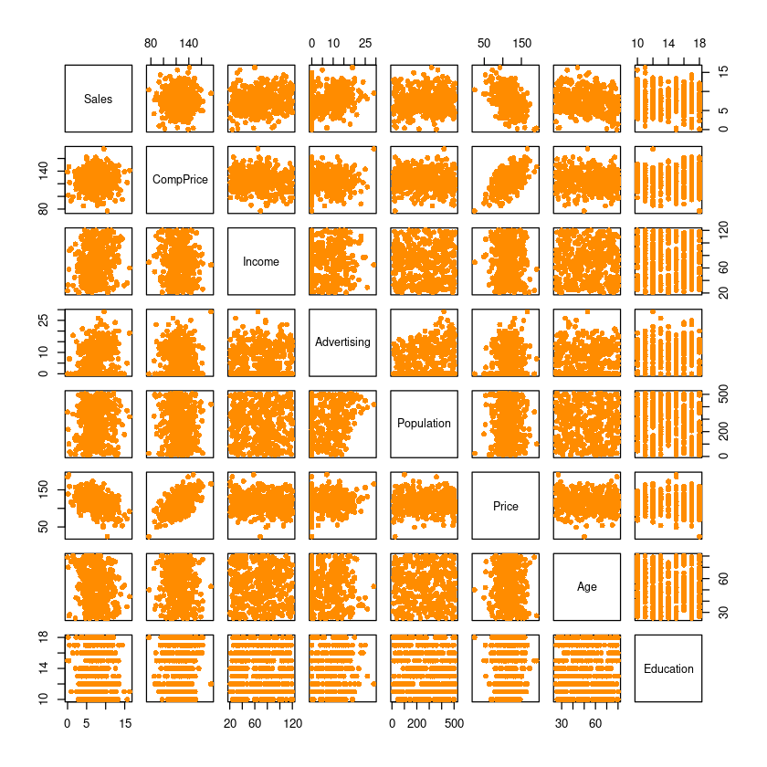

```r
pairs(df, pch=16, col='darkorange')
```

### (2) Sales를 예측하기 위한 중회귀분석을 하려고 한다. 이를 위한 모형을 설정하시오.

$y_i = \beta_0 + \beta_1x_{i1} + \beta_2x_{i2} + \dots \beta_6x_{i6}+\epsilon_i, \quad i=1,2,\dots 400$

- 설명변수(독립변수):

$X_1= CompPrice, X_2=Income, X_3=Advertising, X_4=Population, X_5=Price, X_6=Education$

- 반응변수(종속변수): ${\mathbf y} = Sales$
- 오차항: $\epsilon_1, \epsilon_2, \dots, \epsilon_{400}, \quad (\sim_{i.i.d} N(0,\sigma^2)$

### (3) 최소제곱법의 의한 회귀직선을 적합시키시키고, 모형 적합 결과를 설명하시오.

$S = \sum_{i=1}^n \epsilon_i^2=\sum_{i=1}^n(y_i - (\beta_0 + \beta_1x_{i1} + \dots \beta_6x_{i6}))^2$

최소제곱추정량: $(\hat{\beta}_0, \hat{\beta}_1,\dots, \hat{\beta}_6)=\underset{(\beta_0, \beta_1,\dots,\beta_6)\in \mathbb{R}^3}{\text{argmin}} \sum_{i=1}^n \{y_i - (\beta_0 + \beta_1x_{i1} + \dots \beta_6x_{i6})\}^2$

#### 모형적합 (함수이용)

```r
# df[,which(!(names(df) %in% c('Age')))]
```

```r
fit_Sales <- lm(Sales ~ .-Age, data=df)
# fit_Sales <- lm(Sales ~ CompPrice + Income + Advertising + Population + Price + Education, data=df)
summary(fit_Sales)
```

```
Call:
lm(formula = Sales ~ . - Age, data = df)

Residuals:
    Min      1Q  Median      3Q     Max
-5.9921 -1.4004 -0.1145  1.2378  5.0112

Coefficients:
              Estimate Std. Error t value Pr(>|t|)
(Intercept)  4.5970091  1.1077522   4.150 4.08e-05 ***
CompPrice    0.0971849  0.0083574  11.629  < 2e-16 ***
Income       0.0132566  0.0037106   3.573 0.000397 ***
Advertising  0.1295888  0.0161449   8.027 1.17e-14 ***
Population   0.0001374  0.0007334   0.187 0.851487
Price       -0.0905544  0.0053869 -16.810  < 2e-16 ***
Education   -0.0407910  0.0396398  -1.029 0.304093
---
Signif. codes:  0 ‘***’ 0.001 ‘**’ 0.01 ‘*’ 0.05 ‘.’ 0.1 ‘ ’ 1

Residual standard error: 2.06 on 393 degrees of freedom
Multiple R-squared:  0.4761,    Adjusted R-squared:  0.4681
F-statistic: 59.54 on 6 and 393 DF,  p-value: < 2.2e-16
```

**`(결과해석)`**

$\hat{y} = \hat{\beta}_1x_1 + \hat{\beta}_2x_2 + \hat{\beta}_3x_3 + \hat{\beta}_4x_4 + \hat{\beta}_5x_5 + \hat{\beta}_6x_6 \\ \space\space =4.5970+0.09718x_1 + 0.01325x_2 + 0.1295x_3+0.0001x_4-0.0905x_5-0.0407x_6$

- $x_1= CompPrice, x_2=Income, x_3=Advertising, x_4=Population, x_5=Price, x_6=Education$
- 다른 변수값이 일정할 때, 경쟁사 가격(CompPric)이 1단위 증가하면 총 판매액(Sales)이 평균적으로 $0.09718$ 만큼증가한다.
- 다른 변수값이 일정할 때, 소득수준(Income)이 1단위(1000달러) 증가하면 총 판매액(Sales)이 평균적으로 $0.01325$ 만큼 증가한다.
- 다른 변수값이 일정할 때, 광고비(Advertising)가 1단위(1000달러) 증가하면 총 판매액(Sales)이 평균적으로 $0.1295$ 만큼 증가한다.
- 다른 변수값이 일정할 떄, 사이트 별 카시트 가격(Price)이 1단위 증가하면 총 판매액(Sales)이 평균적으로 $0.0905$ 만큼 감소한다.
- $R^2_{Adj}= 0.4681 $로 적합된 회귀모형이 총 변동의 $46.81\%$ 설명하고 있다.
- 회귀모형의 유의성 검정(F-test) 결과 $p-value < 2.2e-16$ 으로 매우 작으므로 회귀모형이 유의하지 않다는 귀무가설을 기각할 수 있다.
- 개별 회귀계수의 유의성 검정(t-test)결과 유의수준 $5\%$하에서 CompPrice, Income, Advertising, Price 가 유의하다.

#### Matrix

$$\mathbf{y} = \mathbf{X}\mathbf{\beta} + \mathbf{\epsilon} \Rightarrow \hat{\mathbf{\beta}}=(\mathbf{X}^\top X)^{-1}\mathbf{X}^\top \mathbf{y}$$

```r
n = nrow(df)
X = cbind(rep(1,n), df$CompPrice, df$Income, df$Advertising, df$Population, df$Price, df$Education)
y = df$Sales
```

```r
beta_hat = solve(t(X)%*%X) %*% t(X) %*% y
beta_hat
```

A matrix: 7 × 1 of type dbl

| 4.5970090863 |
| --- |
| 0.0971849195 |
| 0.0132566345 |
| 0.1295887568 |
| 0.0001373898 |
| -0.0905544248 |
| -0.0407909986 |

- `lm`을 이용하나 행렬을 이용해서 하나 동일한 결과를 얻음을 확인할 수 있다.

### (4) 회귀직선의 유의성 검정을 위한 가설을 설정하고, 분산분석표를 이용하여 가설 검정을 수행하시오.

$H_0: \beta_1=\beta_2 = \dots = \beta_6 = 0$

$H_1: \text{not } H_0 \quad(\text{최소한 하나의 } \beta_i \neq 0, \quad i=1,2,\dots 6)$

```r
df2 = df[,which(!(names(df) %in% c('Age')))]
colnames(df2)
```

1. 'Sales'

2. 'CompPrice'

3. 'Income'

4. 'Advertising'

5. 'Population'

6. 'Price'

7. 'Education'

```r
anova(fit_Sales)
```

A anova: 7 × 5

|  | Df <int> | Sum Sq <dbl> | Mean Sq <dbl> | F value <dbl> | Pr(>F) <dbl> |
| --- | --- | --- | --- | --- | --- |
| CompPrice | 1 | 13.0666859 | 13.0666859 | 3.08043028 | 8.001871e-02 |
| Income | 1 | 79.0733616 | 79.0733616 | 18.64129736 | 1.999655e-05 |
| Advertising | 1 | 219.3512681 | 219.3512681 | 51.71137454 | 3.269539e-12 |
| Population | 1 | 0.3824026 | 0.3824026 | 0.09015021 | 7.641450e-01 |
| Price | 1 | 1198.8668836 | 1198.8668836 | 282.62911342 | 3.569783e-48 |
| Education | 1 | 4.4918032 | 4.4918032 | 1.05892853 | 3.040926e-01 |
| Residuals | 393 | 1667.0422928 | 4.2418379 | NA | NA |

$H_0: y = \beta_0 \cdot 1 ,\\ H_1: \beta_0 \cdot 1 + \beta_1 x_1 + \beta_2 x_2 + \beta_3 x_3 + \beta_4x_4 + \beta_5x_5 + \beta_6x_6$

```r
null_model <- lm(Sales ~ 1, data=df2) # H0
fit_Sales <- lm(Sales ~ ., data=df2) # H1

anova(null_model, fit_Sales)
```

A anova: 2 × 6

|  | Res.Df <dbl> | RSS <dbl> | Df <dbl> | Sum of Sq <dbl> | F <dbl> | Pr(>F) <dbl> |
| --- | --- | --- | --- | --- | --- | --- |
| 1 | 399 | 3182.275 | NA | NA | NA | NA |
| 2 | 393 | 1667.042 | 6 | 1515.232 | 59.53522 | 3.000393e-52 |

p-value가 매우작은 값으로 유의수준 $5\%$ 하에서 적합된 회귀모형은 유의하다.

```r
400-1 # null model: 잔차항의 자유도 (n-p)
400-6-1 # Full model: 잔차항의 자유도 (n-p-1)
```

399

393

### (5) 오차의 분산에 대한 추정량을 구하시오.

$$SSE = \sum(y_i - \hat{y}_i)^2,\quad RMSE = \sqrt\frac{SSE}{n-p-1} = \hat{\sigma}$$

```r
summary(fit_Sales)$sigma # RMSE
(summary(fit_Sales)$sigma)^2 # MSE
```

2.05957226026746

4.24183789526319

### matrix

```r
n = nrow(df2)
X = as.matrix(cbind(rep(1,n), df2 |> select(2:7)))
#names(X)[names(X)=='rep(1, n)'] <- c('1')
y = df2$Sales
```

```r
beta_hat = solve(t(X) %*% X) %*% t(X) %*% y
y_hat = X %*% beta_hat
sse <- sum((y-y_hat)^2)
sqrt(sse/(n-6-1)) # p=6, RMSE
sse/(n-6-1)
```

2.05957226026746

4.2418378952632

### (6) 결정계수와 수정된 결정계수를 구하시오.

```r
summary(fit_Sales)
```

```
Call:
lm(formula = Sales ~ ., data = df2)

Residuals:
    Min      1Q  Median      3Q     Max
-5.9921 -1.4004 -0.1145  1.2378  5.0112

Coefficients:
              Estimate Std. Error t value Pr(>|t|)
(Intercept)  4.5970091  1.1077522   4.150 4.08e-05 ***
CompPrice    0.0971849  0.0083574  11.629  < 2e-16 ***
Income       0.0132566  0.0037106   3.573 0.000397 ***
Advertising  0.1295888  0.0161449   8.027 1.17e-14 ***
Population   0.0001374  0.0007334   0.187 0.851487
Price       -0.0905544  0.0053869 -16.810  < 2e-16 ***
Education   -0.0407910  0.0396398  -1.029 0.304093
---
Signif. codes:  0 ‘***’ 0.001 ‘**’ 0.01 ‘*’ 0.05 ‘.’ 0.1 ‘ ’ 1

Residual standard error: 2.06 on 393 degrees of freedom
Multiple R-squared:  0.4761,    Adjusted R-squared:  0.4681
F-statistic: 59.54 on 6 and 393 DF,  p-value: < 2.2e-16
```

- $R^2 = 0.4761,R^2=0.4681 $

### (7) 개별 회귀계수의 유의성검정을 수행하시오.

```r
summary(fit_Sales)$coef
```

A matrix: 7 × 4 of type dbl

|  | Estimate | Std. Error | t value | Pr(>\|t\|) |
| --- | --- | --- | --- | --- |
| (Intercept) | 4.5970090863 | 1.1077522094 | 4.1498532 | 4.081124e-05 |
| CompPrice | 0.0971849195 | 0.0083574142 | 11.6285872 | 4.587518e-27 |
| Income | 0.0132566345 | 0.0037106386 | 3.5726019 | 3.973365e-04 |
| Advertising | 0.1295887568 | 0.0161449482 | 8.0265824 | 1.171428e-14 |
| Population | 0.0001373898 | 0.0007333539 | 0.1873444 | 8.514873e-01 |
| Price | -0.0905544248 | 0.0053869071 | -16.8100958 | 3.622042e-48 |
| Education | -0.0407909986 | 0.0396397597 | -1.0290425 | 3.040926e-01 |

유의수준 $5\%$하에서 개별 회귀계수의 유의성 검정 결과 CompPrice, Income, Advertising, Price 변수가 유의하게 나타났다.

### (8) 회귀계수에 대한 90% 신뢰구간을 구하시오.

```r
confint(fit_Sales, level=0.90)
```

A matrix: 7 × 2 of type dbl

|  | 5 % | 95 % |
| --- | --- | --- |
| (Intercept) | 2.770613583 | 6.42340459 |
| CompPrice | 0.083405716 | 0.11096412 |
| Income | 0.007138756 | 0.01937451 |
| Advertising | 0.102969933 | 0.15620758 |
| Population | -0.001071720 | 0.00134650 |
| Price | -0.099436035 | -0.08167281 |
| Education | -0.106146660 | 0.02456466 |

### (9) CompPrice = 100, Income = 70, Advertising = 20, Population = 300, Price = 80, Education = 12

인 지역에 위치한 매장의 평균 판매액을 예측하고, 95% 신뢰구간을 구하시오.

```r
new_df = data.frame(CompPrice=100, Income=70, Advertising = 20, Population = 300, Price = 80, Education = 12)
new_df
```

A data.frame: 1 × 6

| CompPrice <dbl> | Income <dbl> | Advertising <dbl> | Population <dbl> | Price <dbl> | Education <dbl> |
| --- | --- | --- | --- | --- | --- |
| 100 | 70 | 20 | 300 | 80 | 12 |

```r
predict(fit_Sales,
        newdata = new_df,
        interval = c('confidence'),
        level = 0.95) ## 평균반응
```

A matrix: 1 × 3 of type dbl

|  | fit | lwr | upr |
| --- | --- | --- | --- |
| 1 | 10.14261 | 9.537128 | 10.7481 |

### (10) 위 매장에 대하여 개별 판매액 예측하고, 95% 신뢰구간을 구하시오.

```r
predict(fit_Sales,
        newdata = new_df,
        interval = c('prediction'),
        level = 0.95)
```

A matrix: 1 × 3 of type dbl

|  | fit | lwr | upr |
| --- | --- | --- | --- |
| 1 | 10.14261 | 6.048434 | 14.23679 |

### (11) 잔차에 대한 산점도를 그리고, 결과를 설명하여라.

```r
library(ggplot2)
library(lmtest)  ## bptest, dwtest
```

```r
yhat <- fit_Sales$fitted
resid <- fit_Sales$residuals
```

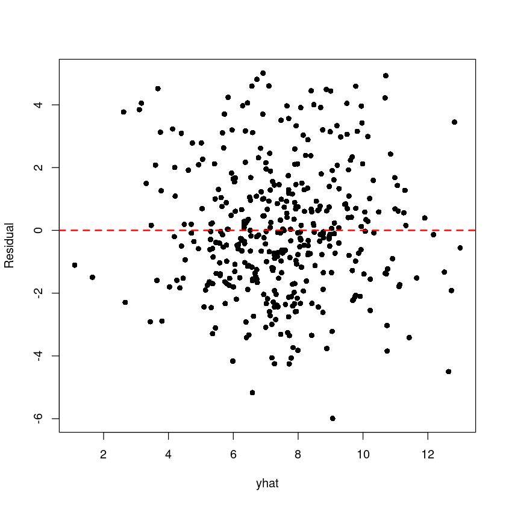

```r
plot(resid ~ yhat, pch=16, ylab='Residual')
abline(h=0, lty=2, lwd=2, col='red')
```

- $0$에 대해 대칭형태를 보이며, 등분산성을 만족하는 것으로 보인다.

### (12) 잔차에 대한 등분산성 검정을 수행하여라.

```r
### 등분산성
## H0 : 등분산  vs.  H1 : 이분산 (Heteroscedasticity)
bptest(fit_Sales)
```

```
    studentized Breusch-Pagan test

data:  fit_Sales
BP = 2.6835, df = 6, p-value = 0.8474
```

유의수준 $5\%$ 하에서 Breusch-Pegan 검정 결과 p-value=0.8474로 유의수준 0.05보다 크므로 귀무가설을 기각할 수 없다. 따라서 잔차가 등분산성을 만족한다고 판단한다.

### (13) 잔차에 대한 히스토그램, QQ plot을 그리고, 정규성 검정을 수행하여라.

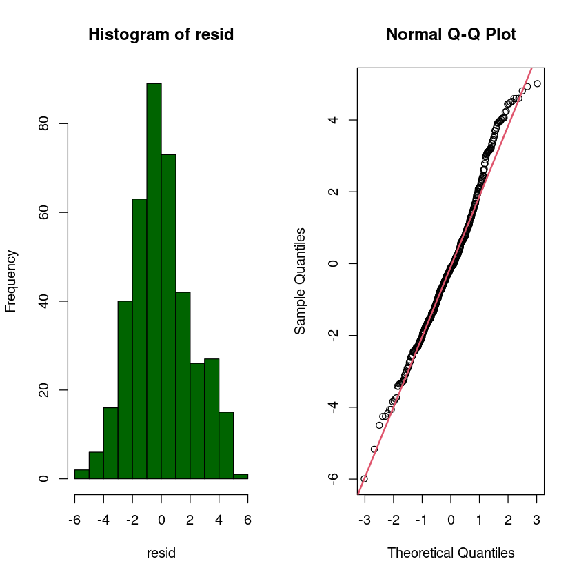

```r
par(mfrow=c(1,2))
hist(resid, col='darkgreen')
qqnorm(resid)
qqline(resid, col=2, lwd=2)
```

- Q-Q Plot의 우상단의 잔차들이 qqline에서 살짝 벗어나 있는 걸로보아 오른쪽으로 살짝 꼬리가 긴 형태를 띄는 것으로 보이지만 그림으로 판단하기에 에매한 것 같다.

```r
## Shapiro-Wilk Test
## H0 : normal distribution  vs. H1 : not H0
shapiro.test(resid)
```

```
    Shapiro-Wilk normality test

data:  resid
W = 0.98887, p-value = 0.003863
```

유의수준 $5\%$ 하에서 Shapiro wilk 정규성 검정 결과 $p-value=0.003863$ 으로 유의수준 $0.05$ 보다 작으므로 정규성을 만족한다는 귀무가설을 기각할 수 있다.따라서 정규성을 따르지 않는 것으로 판단한다.

### (14) 잔차에 대한 독립성 검정을 수행하시오.

```r
dwtest(fit_Sales, alternative = "two.sided")  #H0 : uncorrelated vs H1 : rho != 0
```

```
    Durbin-Watson test

data:  fit_Sales
DW = 1.9677, p-value = 0.7479
alternative hypothesis: true autocorrelation is not 0
```

더빈왓슨 통계량이 $1.9677$로 $2$에 가까우며, $p-valu=0.7479$로 유의수준 $5\%$하에서 잔차가 독립이라는 귀무가설을 기각할 수 없다. 따라서 잔차들간의 correlation이 없다(즉, 독립이다)고 판단한다.

## Q2. 다음 물음에 답하여라.

위 데이터에 대하여 다음 물음에 답하여라. (R을 이용하여 풀이)(검정에서는 유의수준 α = 0.05 사용)

### (1) 위에서 적합한 모형에서 개별 회귀계수의 유의성 검정 결과 유의하지 않은 변수는 무엇인가?

```r
Coefficients:
              Estimate Std. Error t value Pr(>|t|)
(Intercept)  4.5970091  1.1077522   4.150 4.08e-05 ***
CompPrice    0.0971849  0.0083574  11.629  < 2e-16 ***
Income       0.0132566  0.0037106   3.573 0.000397 ***
Advertising  0.1295888  0.0161449   8.027 1.17e-14 ***
Population   0.0001374  0.0007334   0.187 0.851487
Price       -0.0905544  0.0053869 -16.810  < 2e-16 ***
Education   -0.0407910  0.0396398  -1.029 0.304093
```

- $5\%$ 하에서 개별 회귀계수의 유의성 결과 유의수준 `Population`과 `Education`이 유의하지 않았다.

### (2) 위에서 유의하지 않았던 변수를 제외한 모형을 축소모형(Reduced Model)으로 하는 부분 F검정을 수행

하여라. 검정에 필요한 가설을 설정하고, 검정 결과를 설명하시오.

$H_0: \beta_4 = \beta_6 = 0 \quad (RM)\\ H_1: \text{not } H_0$

### (3) 1번에서 설정한 모형과, 축소모형 중 어느 모형이 이 데이터에 대한 설명을 잘 하고 있는지를 비교하시오.

```r
reduced_model = lm(Sales ~ .-Population - Education, data=df2) ## q=4, r=2
# reduced_model = lm(Sales ~ CompPrice + Income + Advertising + Price, data=df2) ## q=4, r=2
full_model = lm(Sales ~ ., data=df2) # 1번에서 설정한 모델. (=fit_Sales) ## p=6
anova(reduced_model, full_model)
```

A anova: 2 × 6

|  | Res.Df <dbl> | RSS <dbl> | Df <dbl> | Sum of Sq <dbl> | F <dbl> | Pr(>F) <dbl> |
| --- | --- | --- | --- | --- | --- | --- |
| 1 | 395 | 1671.898 | NA | NA | NA | NA |
| 2 | 393 | 1667.042 | 2 | 4.856036 | 0.5723976 | 0.5646408 |

```r
p <- full_model$rank - 1
q <- reduced_model$rank-1
SSE_FM <- anova(full_model)$Sum[p+1] #SSE_FM
SSE_RM <- anova(reduced_model)$Sum[q+1] #SSE_RM

F0 <- ((SSE_RM-SSE_FM)/(p-q))/(SSE_FM/(nrow(df2)-p-1))
F0
```

0.572397599860576

```r
## 기각역
qf(0.95,p-q,nrow(df2)-p-1)
```

3.01868441743385

$F_0 < F_{0.05}(2,393)$ 이므로 귀무가설을 기각할 수 없다. 따라서 축소모형이 이 데이터에 대한 설명을 잘 하고 있다고 할 수 있다.

```r
summary(reduced_model)
```

```
Call:
lm(formula = Sales ~ . - Population - Education, data = df2)

Residuals:
    Min      1Q  Median      3Q     Max
-5.8438 -1.4519 -0.1742  1.1659  5.1762

Coefficients:
             Estimate Std. Error t value Pr(>|t|)
(Intercept)  4.077797   0.910848   4.477 9.92e-06 ***
CompPrice    0.096881   0.008309  11.660  < 2e-16 ***
Income       0.013439   0.003699   3.633 0.000317 ***
Advertising  0.130868   0.015559   8.411 7.50e-16 ***
Price       -0.090507   0.005378 -16.830  < 2e-16 ***
---
Signif. codes:  0 ‘***’ 0.001 ‘**’ 0.01 ‘*’ 0.05 ‘.’ 0.1 ‘ ’ 1

Residual standard error: 2.057 on 395 degrees of freedom
Multiple R-squared:  0.4746,    Adjusted R-squared:  0.4693
F-statistic: 89.21 on 4 and 395 DF,  p-value: < 2.2e-16
```

```r
summary(full_model)
```

```
Call:
lm(formula = Sales ~ ., data = df2)

Residuals:
    Min      1Q  Median      3Q     Max
-5.9921 -1.4004 -0.1145  1.2378  5.0112

Coefficients:
              Estimate Std. Error t value Pr(>|t|)
(Intercept)  4.5970091  1.1077522   4.150 4.08e-05 ***
CompPrice    0.0971849  0.0083574  11.629  < 2e-16 ***
Income       0.0132566  0.0037106   3.573 0.000397 ***
Advertising  0.1295888  0.0161449   8.027 1.17e-14 ***
Population   0.0001374  0.0007334   0.187 0.851487
Price       -0.0905544  0.0053869 -16.810  < 2e-16 ***
Education   -0.0407910  0.0396398  -1.029 0.304093
---
Signif. codes:  0 ‘***’ 0.001 ‘**’ 0.01 ‘*’ 0.05 ‘.’ 0.1 ‘ ’ 1

Residual standard error: 2.06 on 393 degrees of freedom
Multiple R-squared:  0.4761,    Adjusted R-squared:  0.4681
F-statistic: 59.54 on 6 and 393 DF,  p-value: < 2.2e-16
```

- 축소모형의 RMSE가 좀 더 줄어들었으며, $R^2_{Adj}$ 값 역시 $0.4693$으로 full모델의 값인 $0.4681$ 보다 좀 더 좋아졌다.

## Q3. 일반 선형 가설검정 (General Linear Hypothesis Test)을 수행하여라.

1번에서 설정한 모형에 대하여 아래의 일반 선형 가설검정(General Linear Hypothesis Test)을 수행하시오. (R을 이용하여 풀이)(검정에서는 유의수준 α = 0.05 사용)(회귀계수는 βi 로 표현해야 하지만, 각자 설정이 다를 수가 있기 때문에 회귀계수 대신 변수 이름을 사용하겠음. 예 β1 =CompPrice)

```r
library(car)
```

```r
fit_Sales ## 1에서 설정한 모델
```

```
Call:
lm(formula = Sales ~ ., data = df2)

Coefficients:
(Intercept)    CompPrice       Income  Advertising   Population        Price
  4.5970091    0.0971849    0.0132566    0.1295888    0.0001374   -0.0905544
  Education
 -0.0407910
```

### (1) $H_0 : \text{CompPrice}=\text{Income} \text{ vs. } H_1 : \text{not } H_0$

```r
# CompPrice-Income = 0 => (0,1,-1,0,0,0,0)*beta
linearHypothesis(fit_Sales, c(0,1,-1,0,0,0,0),0)
```

A anova: 2 × 6

|  | Res.Df <dbl> | RSS <dbl> | Df <dbl> | Sum of Sq <dbl> | F <dbl> | Pr(>F) <dbl> |
| --- | --- | --- | --- | --- | --- | --- |
| 1 | 394 | 2040.234 | NA | NA | NA | NA |
| 2 | 393 | 1667.042 | 1 | 373.1914 | 87.97871 | 5.357559e-19 |

```r
linearHypothesis(fit_Sales, c(0,-1,1,0,0,0,0),0)
```

A anova: 2 × 6

|  | Res.Df <dbl> | RSS <dbl> | Df <dbl> | Sum of Sq <dbl> | F <dbl> | Pr(>F) <dbl> |
| --- | --- | --- | --- | --- | --- | --- |
| 1 | 394 | 2040.234 | NA | NA | NA | NA |
| 2 | 393 | 1667.042 | 1 | 373.1914 | 87.97871 | 5.357559e-19 |

### (2) $H_0 : \text{CompPrice}= -\text{Price} \text{ vs. } H_1 : \text{not } H_0$

```r
# H_0: Comprice + Price = 0
linearHypothesis(fit_Sales, c(0,1,0,0,0,-1,0),0)
```

A anova: 2 × 6

|  | Res.Df <dbl> | RSS <dbl> | Df <dbl> | Sum of Sq <dbl> | F <dbl> | Pr(>F) <dbl> |
| --- | --- | --- | --- | --- | --- | --- |
| 1 | 394 | 2653.572 | NA | NA | NA | NA |
| 2 | 393 | 1667.042 | 1 | 986.5296 | 232.5713 | 1.403571e-41 |

```r
linearHypothesis(fit_Sales, c(0,-1,0,0,0,1,0),0)
```

A anova: 2 × 6

|  | Res.Df <dbl> | RSS <dbl> | Df <dbl> | Sum of Sq <dbl> | F <dbl> | Pr(>F) <dbl> |
| --- | --- | --- | --- | --- | --- | --- |
| 1 | 394 | 2653.572 | NA | NA | NA | NA |
| 2 | 393 | 1667.042 | 1 | 986.5296 | 232.5713 | 1.403571e-41 |

### (3) $H_0$를 기각할 수 있는 제약조건을 만들어 보시오.(단 2개 이상의 변수 사용)

```r
# H_0: Income = Advertising
linearHypothesis(fit_Sales, c(0,0,1,-1,0,0,0),0)
```

A anova: 2 × 6

|  | Res.Df <dbl> | RSS <dbl> | Df <dbl> | Sum of Sq <dbl> | F <dbl> | Pr(>F) <dbl> |
| --- | --- | --- | --- | --- | --- | --- |
| 1 | 394 | 1870.519 | NA | NA | NA | NA |
| 2 | 393 | 1667.042 | 1 | 203.4765 | 47.96894 | 1.776524e-11 |

```r
# H_0: Income = Advertising+2
linearHypothesis(fit_Sales, c(0,0,1,-1,0,0,0),2)
```

A anova: 2 × 6

|  | Res.Df <dbl> | RSS <dbl> | Df <dbl> | Sum of Sq <dbl> | F <dbl> | Pr(>F) <dbl> |
| --- | --- | --- | --- | --- | --- | --- |
| 1 | 394 | 69008.501 | NA | NA | NA | NA |
| 2 | 393 | 1667.042 | 1 | 67341.46 | 15875.54 | 7.549323e-320 |